# Predicting examination scores based on study hours

## Background of the problem

- You have a small [dataset](https://raw.githubusercontent.com/AdiPersonalWorks/Random/master/student_scores%20-%20student_scores.csv) of students’ **hours of studying** and their corresponding **scores** for an examination.
- You want to **model the relationship** of the students’ studying hours and their examination scores.
- Using this model, you want to **predict** the **examination score** of a student if s/he studied for **9.25 hours**.

## Supervised Machine Learning

- In **supervised machine learning**, we have our **input** variables (ie. predictor or independent variables) that are passed into a **function** that will produce an **output** (ie. response, dependent variables)

\[ Y = f(X) \]

- A **regression problem** is when the output variable is a **real value**, such as “dollars” or “weight”.
- A **classification problem** is when the output variable is a **category**, such as “red” or “blue” or “disease” and “no disease”.

## What is linear regression?

- **Linear regression** models the relationship between two variables by fitting a linear equation to the observed data ([www.stat.yale.edu](http://www.stat.yale.edu/Courses/1997-98/101/linreg.htm)).

\(Y = \beta_0 + \beta_1X + \epsilon\)

\(Y = \beta_0 + \beta_1X_1 + \beta_2X_2 + \beta_3X_3 + ... + \beta_nX_n + \epsilon\) where \(n\) = number of input variables

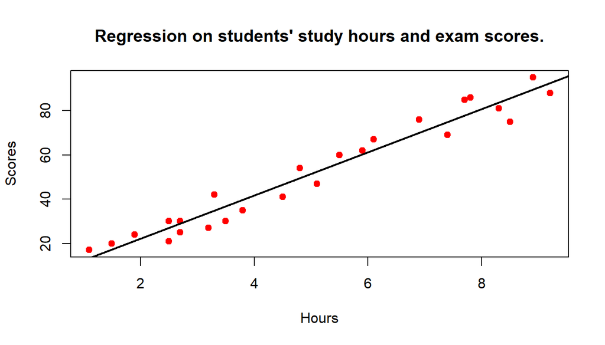

## About the data

```r
# read the data from source
student_data = read.csv('student_scores - student_scores.csv')

# view first few rows
head(student_data)
```

```
##   Hours Scores
## 1   2.5     21
## 2   5.1     47
## 3   3.2     27
## 4   8.5     75
## 5   3.5     30
## 6   1.5     20
```

```r
# get number of rows and columns
dim(student_data)
```

```
## [1] 25  2
```

## Training the model

```r
# train the linear regression model
lin_reg_model = lm(Scores ~ Hours, student_data)
summary(lin_reg_model)
```

```
##
## Call:
## lm(formula = Scores ~ Hours, data = student_data)
##
## Residuals:
##     Min      1Q  Median      3Q     Max
## -10.578  -5.340   1.839   4.593   7.265
##
## Coefficients:
##             Estimate Std. Error t value Pr(>|t|)
## (Intercept)   2.4837     2.5317   0.981    0.337
## Hours         9.7758     0.4529  21.583   <2e-16 ***
## ---
## Signif. codes:  0 '***' 0.001 '**' 0.01 '*' 0.05 '.' 0.1 ' ' 1
##
## Residual standard error: 5.603 on 23 degrees of freedom
## Multiple R-squared:  0.9529, Adjusted R-squared:  0.9509
## F-statistic: 465.8 on 1 and 23 DF,  p-value: < 2.2e-16
```

## Understanding regression output: Residuals

`Residuals` section displays the 5-number summary of the residuals. **Residuals** are the distances between the actual response variable and the predicted value.

```
##    Min. 1st Qu.  Median    Mean 3rd Qu.    Max.
## -10.578  -5.340   1.839   0.000   4.592   7.265
```

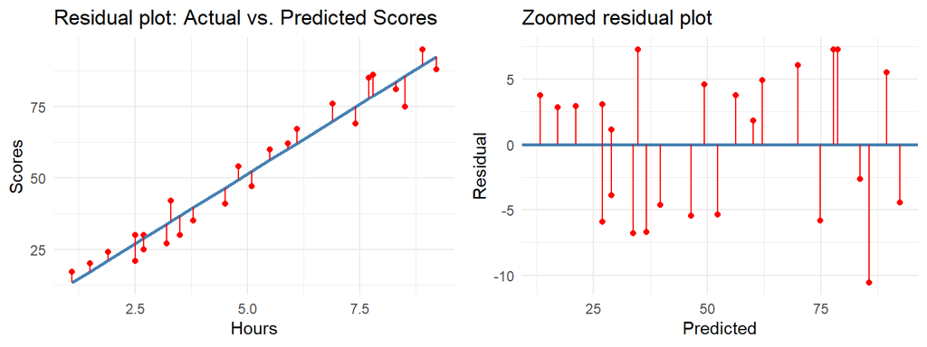

## Understanding regression output: Coefficients

The linear regression model is represented by the equation \(Y = \beta_0 + \beta_1X + \epsilon\). The Coefficients are the estimated values of the \(\beta\)’s or constants in the linear regression model.

\(\beta_0\) (Intercept) is the value of \(Y\) when \(X\) is 0. \(\beta_1\) is the unit change in \(Y\) for every unit change in \(X\). Depending on the number of variables, linear regression output can have multiple \(\beta\).

`Pr(>|t|)` tells us if the values of the coefficients are statistically significant.

```
##             Estimate Std. Error    t value     Pr(>|t|)
## (Intercept) 2.483673  2.5316629  0.9810443 3.367785e-01
## Hours       9.775803  0.4529414 21.5829313 9.132624e-17
```

## Understanding regression output: Multiple and Adjusted R-squared

R-Squared is the “goodness of fit” measure in linear regression. This is the percentage of the variability of the response variable which is explained by the model.

Adjusted R-Squared does the same. Adjusted R-Squared will be penalized if we’re adding terms/variables that aren’t useful, and it increases when we’re adding meaningful variables.

Low R-squared doesn’t necessarily mean that your model is useless.

```
## Multiple R-squared:  0.9529  Adjusted R-squared:  0.9509
```

## Predicting using the model

```r
new_data = data.frame(Hours = 9.25)
predict(lin_reg_model, newdata = new_data)
```

```
##        1
## 92.90985
```

```r
predict(lin_reg_model, newdata = new_data, interval = 'confidence')
```

```
##        fit     lwr      upr
## 1 92.90985 88.3118 97.50791
```

## Confidence interval of the linear regression model

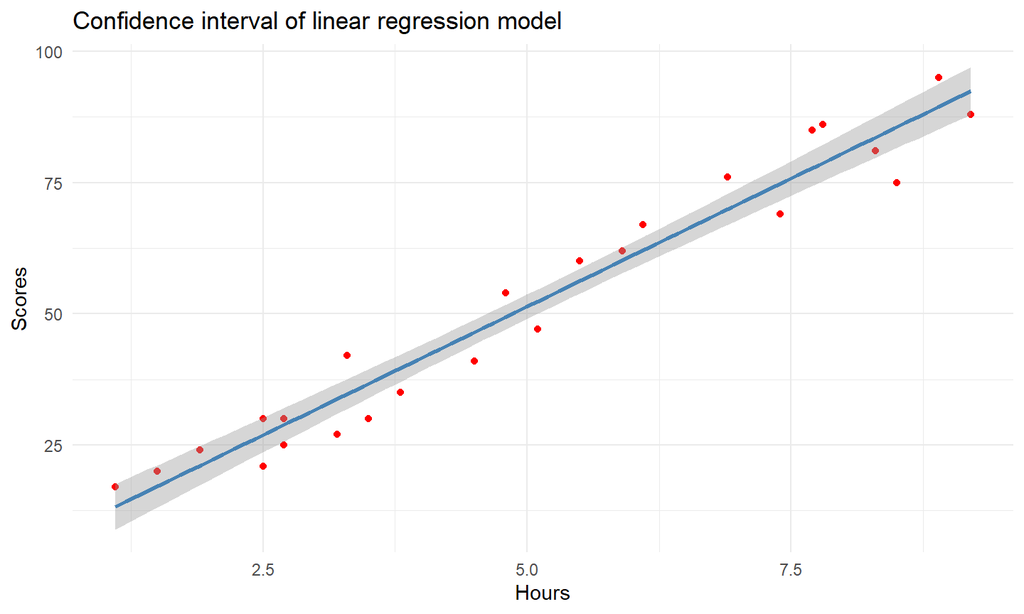

## Summary

Using linear regression, we have modeled the relationship of study hours and exam scores. The model can be written \(Y = 2.48 + 9.78X\).

Having a Multiple R-squared of **0.9529** and adjusted R-squared of **0.9509**, the model predicts with high accuracy.

The patterns on residual plot is something that we could look further.

When a student studied for **9.25** hours, s/he could score between **88.31** to **97.51** points following a **95% confidence interval**.